# Homework 4

Ferhat Turhan

1/18/2022

# Forecasting The Hourly Solar Power Production

In this forecasting problem, the aim is to find a model providing hourly solar power prediction for the next day. This prediction is needed in the following setting. Suppose that you are at day d and the predictions are needed for the day d+1 and you know the production values until the end of d-1. The proposed model is using the regression tree-based approach.

In the provided data there are 175 variables that can be used in the regression model. These variables are a collection of temperature, relative humidity, downward shortwave radiation flux and cloud cover data. Instead of spending too much time to understand the background information about these variables a data-driven approach is used to understand its relation to production levels.

Linear regression is used as the base learner for the tree-based regression approach. For the tree learning, the depth parameter is fixed to 4 and complexity parameter is fixed to 0 to save time.

As the base model for prediction, a very basic model is used, as proposed in the definition of the task, which is using last available data (lag 48 production → two day’s ago).

## Data Manipulation

First of all some manipulations are needed. These are adding trend variable, week day and month information. Then data is ordered and split into two parts as train and test data.

Now that necessary manipulations are made, it’s time to move on building the prediction models.

## Base Model

After building up the prediction model for the hourly solar power, a base model will be needed for comparison reasons. Therefore a base model for predictions is built as proposed in the description of the task. In this base model, the most recent production values (day d-1) is used to predict the next day’s (day d+1) production values. Head of the prediction values by using this model is as following:

```
##               datetime actual base_model
## 1: 2021-11-01 00:00:00 0.0000          0
## 2: 2021-11-01 01:00:00 0.0000          0
## 3: 2021-11-01 02:00:00 0.0002          0
## 4: 2021-11-01 03:00:00 0.0001          0
## 5: 2021-11-01 04:00:00 0.0157          0
## 6: 2021-11-01 05:00:00 0.0000          0
```

## Regression Tree Approach

Here tree-based regression approach is used to predict hourly solar power production. The depth parameter is fixed to 4 and complexity parameter is fixed to 0 to save time. And as the base learner, linear regression is used.

```
##
## Call:
## lm(formula = production ~ trend + w_day + mon + as.factor(hour),
##     data = train_data)
##
## Residuals:
##      Min       1Q   Median       3Q      Max
## -202.725  -18.792    1.477   27.842  106.046
##
## Coefficients:
##                     Estimate Std. Error t value Pr(>|t|)
## (Intercept)       -8.132e+00  1.961e+00  -4.147 3.39e-05 ***
## trend              5.781e-04  5.620e-05  10.287  < 2e-16 ***
## w_dayMon           2.771e+00  1.085e+00   2.553   0.0107 *
## w_daySat           1.847e+00  1.085e+00   1.703   0.0886 .
## w_daySun           5.199e+00  1.083e+00   4.802 1.58e-06 ***
## w_dayThu           2.182e+00  1.087e+00   2.007   0.0448 *
## w_dayTue           4.272e+00  1.086e+00   3.936 8.33e-05 ***
## w_dayWed           2.285e+00  1.085e+00   2.106   0.0352 *
## monAug             1.962e+01  1.486e+00  13.203  < 2e-16 ***
## monDec            -3.452e+01  1.486e+00 -23.234  < 2e-16 ***
## monFeb            -1.427e+01  1.511e+00  -9.444  < 2e-16 ***
## monJan            -3.243e+01  1.481e+00 -21.894  < 2e-16 ***
## monJul             2.777e+01  1.482e+00  18.747  < 2e-16 ***
## monJun             2.069e+01  1.491e+00  13.877  < 2e-16 ***
## monMar            -1.138e+01  1.478e+00  -7.702 1.41e-14 ***
## monMay             1.731e+01  1.478e+00  11.714  < 2e-16 ***
## monNov            -1.288e+01  1.503e+00  -8.570  < 2e-16 ***
## monOct             1.773e+00  1.353e+00   1.310   0.1901
## monSep             1.144e+01  1.360e+00   8.413  < 2e-16 ***
## as.factor(hour)1  -1.782e-03  2.008e+00  -0.001   0.9993
## as.factor(hour)2  -2.374e-03  2.008e+00  -0.001   0.9991
## as.factor(hour)3  -1.400e-04  2.008e+00   0.000   0.9999
## as.factor(hour)4   1.611e-02  2.008e+00   0.008   0.9936
## as.factor(hour)5   6.283e-01  2.008e+00   0.313   0.7544
## as.factor(hour)6   7.992e+00  2.008e+00   3.980 6.92e-05 ***
## as.factor(hour)7   4.032e+01  2.008e+00  20.077  < 2e-16 ***
## as.factor(hour)8   9.761e+01  2.008e+00  48.605  < 2e-16 ***
## as.factor(hour)9   1.557e+02  2.008e+00  77.551  < 2e-16 ***
## as.factor(hour)10  1.985e+02  2.008e+00  98.856  < 2e-16 ***
## as.factor(hour)11  2.209e+02  2.008e+00 109.990  < 2e-16 ***
## as.factor(hour)12  2.261e+02  2.008e+00 112.595  < 2e-16 ***
## as.factor(hour)13  2.162e+02  2.008e+00 107.645  < 2e-16 ***
## as.factor(hour)14  1.919e+02  2.008e+00  95.568  < 2e-16 ***
## as.factor(hour)15  1.500e+02  2.008e+00  74.697  < 2e-16 ***
## as.factor(hour)16  9.594e+01  2.008e+00  47.774  < 2e-16 ***
## as.factor(hour)17  4.290e+01  2.008e+00  21.363  < 2e-16 ***
## as.factor(hour)18  1.062e+01  2.008e+00   5.288 1.25e-07 ***
## as.factor(hour)19  1.080e+00  2.008e+00   0.538   0.5906
## as.factor(hour)20  3.718e-03  2.008e+00   0.002   0.9985
## as.factor(hour)21 -5.124e-03  2.008e+00  -0.003   0.9980
## as.factor(hour)22 -1.742e-02  2.008e+00  -0.009   0.9931
## as.factor(hour)23 -1.722e-02  2.008e+00  -0.009   0.9932
## ---
## Signif. codes:  0 '***' 0.001 '**' 0.01 '*' 0.05 '.' 0.1 ' ' 1
##
## Residual standard error: 39.94 on 18942 degrees of freedom
## Multiple R-squared:  0.831,  Adjusted R-squared:  0.8307
## F-statistic:  2272 on 41 and 18942 DF,  p-value: < 2.2e-16
```

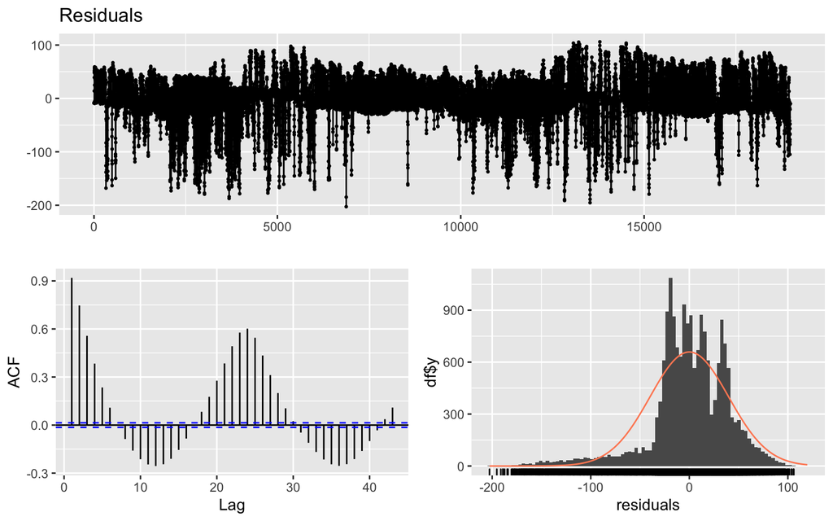

```
##
##  Breusch-Godfrey test for serial correlation of order up to 45
##
## data:  Residuals
## LM test = 17607, df = 45, p-value < 2.2e-16
```

By looking at the summary of the base model, it can be said that adjusted r-squared value seems to be fine. And from the residual analysis, this model doesn’t hold the assumptions about residuals, which are having zero mean, not being auto correlated and the normality assumption. Thus, I will add a lag 1 variable in the beginning to get rid of this auto correlation even if it is going to be a slight change.

```
##
## Call:
## lm(formula = production ~ trend + w_day + mon + as.factor(hour) +
##     lag_1, data = train_data)
##
## Residuals:
##      Min       1Q   Median       3Q      Max
## -126.838   -2.551    0.260    5.334   96.103
##
## Coefficients:
##                     Estimate Std. Error t value Pr(>|t|)
## (Intercept)       -6.528e-01  7.730e-01  -0.844 0.398407
## trend              4.670e-05  2.220e-05   2.104 0.035373 *
## w_dayMon           2.244e-01  4.275e-01   0.525 0.599708
## w_daySat           1.496e-01  4.272e-01   0.350 0.726218
## w_daySun           4.204e-01  4.267e-01   0.985 0.324528
## w_dayThu           1.765e-01  4.282e-01   0.412 0.680297
## w_dayTue           3.452e-01  4.277e-01   0.807 0.419667
## w_dayWed           1.850e-01  4.273e-01   0.433 0.665151
## monAug             1.586e+00  5.881e-01   2.697 0.007009 **
## monDec            -2.789e+00  5.934e-01  -4.701 2.61e-06 ***
## monFeb            -1.153e+00  5.963e-01  -1.933 0.053217 .
## monJan            -2.621e+00  5.908e-01  -4.437 9.19e-06 ***
## monJul             2.244e+00  5.889e-01   3.811 0.000139 ***
## monJun             1.672e+00  5.902e-01   2.833 0.004617 **
## monMar            -9.196e-01  5.828e-01  -1.578 0.114610
## monMay             1.399e+00  5.840e-01   2.395 0.016638 *
## monNov            -1.041e+00  5.930e-01  -1.755 0.079260 .
## monOct             1.433e-01  5.329e-01   0.269 0.788048
## monSep             9.245e-01  5.365e-01   1.723 0.084839 .
## as.factor(hour)1  -5.729e-03  7.911e-01  -0.007 0.994222
## as.factor(hour)2  -4.683e-03  7.911e-01  -0.006 0.995277
## as.factor(hour)3  -1.905e-03  7.911e-01  -0.002 0.998078
## as.factor(hour)4   1.229e-02  7.911e-01   0.016 0.987603
## as.factor(hour)5   6.095e-01  7.911e-01   0.770 0.441023
## as.factor(hour)6   7.411e+00  7.911e-01   9.367  < 2e-16 ***
## as.factor(hour)7   3.297e+01  7.915e-01  41.653  < 2e-16 ***
## as.factor(hour)8   6.054e+01  7.995e-01  75.727  < 2e-16 ***
## as.factor(hour)9   6.601e+01  8.390e-01  78.680  < 2e-16 ***
## as.factor(hour)10  5.536e+01  9.080e-01  60.975  < 2e-16 ***
## as.factor(hour)11  3.840e+01  9.739e-01  39.424  < 2e-16 ***
## as.factor(hour)12  2.308e+01  1.013e+00  22.790  < 2e-16 ***
## as.factor(hour)13  8.327e+00  1.022e+00   8.148 3.93e-16 ***
## as.factor(hour)14 -6.789e+00  1.004e+00  -6.760 1.42e-11 ***
## as.factor(hour)15 -2.641e+01  9.630e-01 -27.422  < 2e-16 ***
## as.factor(hour)16 -4.195e+01  9.001e-01 -46.606  < 2e-16 ***
## as.factor(hour)17 -4.529e+01  8.374e-01 -54.083  < 2e-16 ***
## as.factor(hour)18 -2.882e+01  8.006e-01 -35.995  < 2e-16 ***
## as.factor(hour)19 -8.685e+00  7.917e-01 -10.970  < 2e-16 ***
## as.factor(hour)20 -9.932e-01  7.911e-01  -1.255 0.209345
## as.factor(hour)21 -1.249e-02  7.911e-01  -0.016 0.987406
## as.factor(hour)22 -1.666e-02  7.911e-01  -0.021 0.983197
## as.factor(hour)23 -5.147e-03  7.911e-01  -0.007 0.994809
## lag_1              9.192e-01  2.862e-03 321.223  < 2e-16 ***
## ---
## Signif. codes:  0 '***' 0.001 '**' 0.01 '*' 0.05 '.' 0.1 ' ' 1
##
## Residual standard error: 15.73 on 18940 degrees of freedom
##   (1 observation deleted due to missingness)
## Multiple R-squared:  0.9738, Adjusted R-squared:  0.9737
## F-statistic: 1.676e+04 on 42 and 18940 DF,  p-value: < 2.2e-16
```

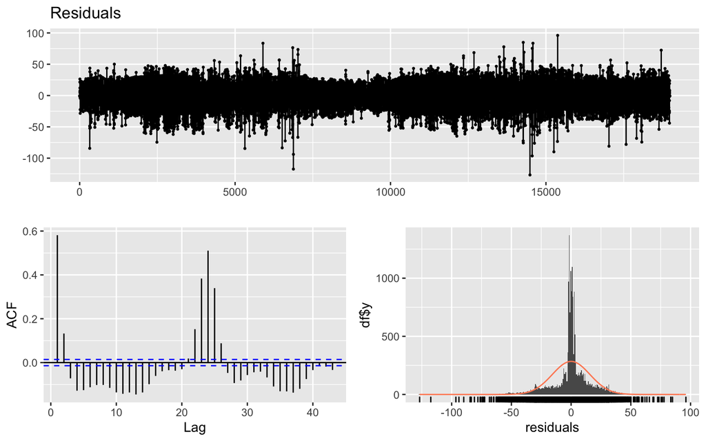

```
##
##  Breusch-Godfrey test for serial correlation of order up to 46
##
## data:  Residuals
## LM test = 10146, df = 46, p-value < 2.2e-16
```

Now that I added lag variable, residual standard error and adjusted r-squared values are much better than before. Residuals seems to be in a better situation. Even though some assumptions still don’t hold, it is a better base learner for the regression tree. Even though this model shows that day effect is not significant, I will keep it until processing the tree based approach. After all I will decide whether to keep it or not. Now let’s move on building up regression trees.

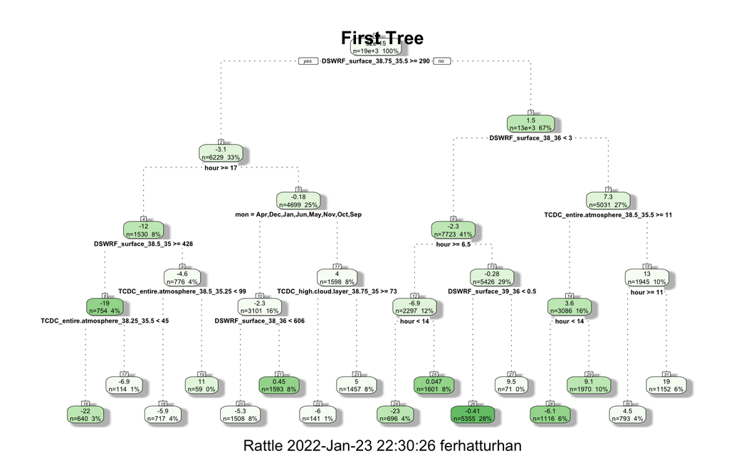

After the first regression tree, the proposed variables affecting residuals are processed to have a better regression model. Following is the updated regression model.

```
##
## Call:
## lm(formula = production ~ trend + w_day + mon + as.factor(hour) +
##     lag_1 + v1:v2:v3:v4, data = temp)
##
## Residuals:
##      Min       1Q   Median       3Q      Max
## -125.424   -1.564    0.099    5.500   97.518
##
## Coefficients:
##                     Estimate Std. Error t value Pr(>|t|)
## (Intercept)       -1.914e+00  7.144e-01  -2.679 0.007386 **
## trend              4.188e-05  2.050e-05   2.043 0.041090 *
## w_dayMon           1.725e-01  3.949e-01   0.437 0.662207
## w_daySat           1.093e-01  3.947e-01   0.277 0.781814
## w_daySun           3.729e-01  3.942e-01   0.946 0.344184
## w_dayThu           1.494e-01  3.956e-01   0.378 0.705680
## w_dayTue           3.046e-01  3.951e-01   0.771 0.440797
## w_dayWed           1.743e-01  3.948e-01   0.442 0.658781
## monAug             1.399e+00  5.432e-01   2.576 0.009997 **
## monDec             9.380e-01  5.520e-01   1.699 0.089297 .
## monFeb             2.017e+00  5.536e-01   3.644 0.000270 ***
## monJan             8.487e-01  5.491e-01   1.546 0.122220
## monJul             2.065e+00  5.440e-01   3.797 0.000147 ***
## monJun             1.489e+00  5.453e-01   2.730 0.006345 **
## monMar             8.098e-01  5.392e-01   1.502 0.133184
## monMay             1.253e+00  5.395e-01   2.322 0.020243 *
## monNov             1.826e+00  5.501e-01   3.319 0.000904 ***
## monOct             1.763e+00  4.931e-01   3.575 0.000351 ***
## monSep             1.427e+00  4.956e-01   2.880 0.003987 **
## as.factor(hour)1  -4.698e-03  7.308e-01  -0.006 0.994871
## as.factor(hour)2  -3.649e-03  7.308e-01  -0.005 0.996016
## as.factor(hour)3  -8.669e-04  7.308e-01  -0.001 0.999054
## as.factor(hour)4   1.334e-02  7.308e-01   0.018 0.985435
## as.factor(hour)5   6.106e-01  7.308e-01   0.836 0.403413
## as.factor(hour)6   7.413e+00  7.308e-01  10.144  < 2e-16 ***
## as.factor(hour)7   5.716e+01  8.451e-01  67.631  < 2e-16 ***
## as.factor(hour)8   7.259e+01  7.681e-01  94.507  < 2e-16 ***
## as.factor(hour)9   6.796e+01  7.758e-01  87.601  < 2e-16 ***
## as.factor(hour)10  5.565e+01  8.388e-01  66.349  < 2e-16 ***
## as.factor(hour)11  3.876e+01  8.997e-01  43.084  < 2e-16 ***
## as.factor(hour)12  2.348e+01  9.354e-01  25.106  < 2e-16 ***
## as.factor(hour)13  8.744e+00  9.441e-01   9.262  < 2e-16 ***
## as.factor(hour)14 -6.390e+00  9.277e-01  -6.888 5.84e-12 ***
## as.factor(hour)15 -2.605e+01  8.896e-01 -29.286  < 2e-16 ***
## as.factor(hour)16 -4.167e+01  8.314e-01 -50.118  < 2e-16 ***
## as.factor(hour)17 -4.511e+01  7.736e-01 -58.317  < 2e-16 ***
## as.factor(hour)18 -2.874e+01  7.395e-01 -38.858  < 2e-16 ***
## as.factor(hour)19 -8.644e+00  7.316e-01 -11.816  < 2e-16 ***
## as.factor(hour)20 -9.901e-01  7.308e-01  -1.355 0.175515
## as.factor(hour)21 -1.133e-02  7.308e-01  -0.016 0.987628
## as.factor(hour)22 -1.552e-02  7.308e-01  -0.021 0.983061
## as.factor(hour)23 -4.019e-03  7.308e-01  -0.005 0.995613
## lag_1              9.174e-01  2.644e-03 347.014  < 2e-16 ***
## v1:v2:v3:v4       -4.366e+01  7.650e-01 -57.063  < 2e-16 ***
## ---
## Signif. codes:  0 '***' 0.001 '**' 0.01 '*' 0.05 '.' 0.1 ' ' 1
##
## Residual standard error: 14.53 on 18938 degrees of freedom
##   (2 observations deleted due to missingness)
## Multiple R-squared:  0.9776, Adjusted R-squared:  0.9776
## F-statistic: 1.926e+04 on 43 and 18938 DF,  p-value: < 2.2e-16
```

After the first iteration, residual standard error decreased very slightly and adjusted r-squared is improved slightly. We should continue the next iterations.

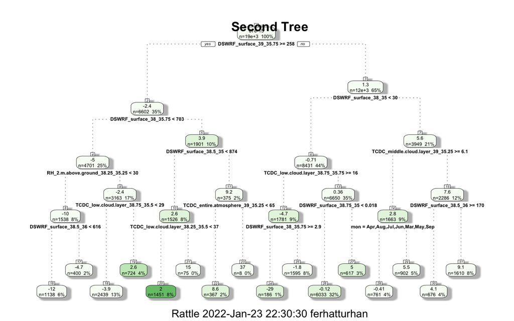

After the second regression tree, the proposed variables affecting residuals are processed to have a better regression model. Following is the updated regression model.

```
##
## Call:
## lm(formula = production ~ trend + w_day + mon + as.factor(hour) +
##     lag_1 + v1:v2:v3:v4 + v5:v6:v7:v8, data = temp)
##
## Residuals:
##      Min       1Q   Median       3Q      Max
## -125.372   -1.545    0.117    5.527   97.608
##
## Coefficients:
##                     Estimate Std. Error t value Pr(>|t|)
## (Intercept)       -1.921e+00  7.135e-01  -2.693 0.007095 **
## trend              4.297e-05  2.048e-05   2.098 0.035905 *
## w_dayMon           2.001e-01  3.944e-01   0.507 0.611918
## w_daySat           8.258e-02  3.942e-01   0.209 0.834060
## w_daySun           3.995e-01  3.937e-01   1.015 0.310148
## w_dayThu           1.480e-01  3.951e-01   0.375 0.707888
## w_dayTue           3.318e-01  3.946e-01   0.841 0.400464
## w_dayWed           2.010e-01  3.943e-01   0.510 0.610155
## monAug             1.390e+00  5.425e-01   2.562 0.010419 *
## monDec             9.510e-01  5.513e-01   1.725 0.084542 .
## monFeb             2.025e+00  5.529e-01   3.662 0.000251 ***
## monJan             8.619e-01  5.484e-01   1.572 0.116040
## monJul             2.057e+00  5.432e-01   3.786 0.000154 ***
## monJun             1.378e+00  5.448e-01   2.529 0.011446 *
## monMar             8.127e-01  5.385e-01   1.509 0.131300
## monMay             1.149e+00  5.390e-01   2.132 0.033061 *
## monNov             1.835e+00  5.493e-01   3.341 0.000837 ***
## monOct             1.764e+00  4.924e-01   3.582 0.000342 ***
## monSep             1.425e+00  4.950e-01   2.878 0.004008 **
## as.factor(hour)1  -4.721e-03  7.298e-01  -0.006 0.994839
## as.factor(hour)2  -3.673e-03  7.298e-01  -0.005 0.995984
## as.factor(hour)3  -8.921e-04  7.298e-01  -0.001 0.999025
## as.factor(hour)4   1.331e-02  7.298e-01   0.018 0.985445
## as.factor(hour)5   6.106e-01  7.298e-01   0.837 0.402816
## as.factor(hour)6   7.413e+00  7.298e-01  10.157  < 2e-16 ***
## as.factor(hour)7   5.717e+01  8.440e-01  67.736  < 2e-16 ***
## as.factor(hour)8   7.259e+01  7.671e-01  94.629  < 2e-16 ***
## as.factor(hour)9   6.793e+01  7.747e-01  87.687  < 2e-16 ***
## as.factor(hour)10  5.561e+01  8.377e-01  66.390  < 2e-16 ***
```

[output cut: 8 more lines]

```
## as.factor(hour)19 -8.647e+00  7.306e-01 -11.836  < 2e-16 ***
## as.factor(hour)20 -9.904e-01  7.298e-01  -1.357 0.174808
## as.factor(hour)21 -1.138e-02  7.298e-01  -0.016 0.987558
## as.factor(hour)22 -1.556e-02  7.298e-01  -0.021 0.982986
## as.factor(hour)23 -4.065e-03  7.298e-01  -0.006 0.995557
## lag_1              9.176e-01  2.640e-03 347.537  < 2e-16 ***
## v1:v2:v3:v4       -4.368e+01  7.640e-01 -57.174  < 2e-16 ***
## v5:v6:v7:v8        3.679e+01  5.146e+00   7.150 9.02e-13 ***
## ---
## Signif. codes:  0 '***' 0.001 '**' 0.01 '*' 0.05 '.' 0.1 ' ' 1
##
## Residual standard error: 14.51 on 18937 degrees of freedom
##   (2 observations deleted due to missingness)
## Multiple R-squared:  0.9777, Adjusted R-squared:  0.9776
## F-statistic: 1.887e+04 on 44 and 18937 DF,  p-value: < 2.2e-16
```

After the second iteration, residual standard error decreased very very little but adjusted r-squared didn’t change. We should continue the third and the last iteration for the scope of this task.

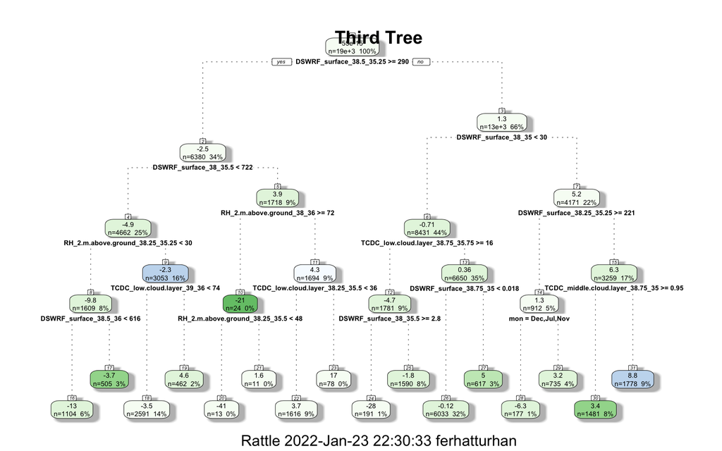

After the third regression tree, the proposed variables affecting residuals are processed to have a better regression model. Following is the updated regression model.

```
##
## Call:
## lm(formula = production ~ trend + w_day + mon + as.factor(hour) +
##     lag_1 + v1:v2:v3:v4 + v5:v6:v7:v8 + v9:v10:v11:v12, data = temp)
##
## Residuals:
##      Min       1Q   Median       3Q      Max
## -125.502   -1.553    0.103    5.481   97.406
##
## Coefficients:
##                     Estimate Std. Error t value Pr(>|t|)
## (Intercept)       -1.869e+00  7.116e-01  -2.626 0.008638 **
## trend              3.924e-05  2.043e-05   1.921 0.054745 .
## w_dayMon           1.841e-01  3.934e-01   0.468 0.639862
## w_daySat           1.440e-01  3.932e-01   0.366 0.714117
## w_daySun           3.866e-01  3.926e-01   0.985 0.324794
## w_dayThu           2.251e-01  3.941e-01   0.571 0.567869
## w_dayTue           3.304e-01  3.935e-01   0.840 0.401074
## w_dayWed           1.854e-01  3.932e-01   0.471 0.637363
## monAug             1.358e+00  5.411e-01   2.509 0.012108 *
## monDec             8.630e-01  5.499e-01   1.569 0.116579
## monFeb             1.952e+00  5.515e-01   3.539 0.000403 ***
## monJan             7.769e-01  5.470e-01   1.420 0.155553
## monJul             2.022e+00  5.418e-01   3.732 0.000190 ***
## monJun             1.569e+00  5.437e-01   2.886 0.003901 **
## monMar             7.489e-01  5.371e-01   1.394 0.163259
## monMay             1.189e+00  5.375e-01   2.211 0.027014 *
## monNov             1.756e+00  5.479e-01   3.204 0.001356 **
## monOct             1.706e+00  4.911e-01   3.474 0.000514 ***
## monSep             1.372e+00  4.937e-01   2.779 0.005453 **
## as.factor(hour)1  -4.699e-03  7.279e-01  -0.006 0.994849
## as.factor(hour)2  -3.648e-03  7.279e-01  -0.005 0.996001
## as.factor(hour)3  -8.631e-04  7.279e-01  -0.001 0.999054
## as.factor(hour)4   1.335e-02  7.279e-01   0.018 0.985368
## as.factor(hour)5   6.106e-01  7.279e-01   0.839 0.401511
## as.factor(hour)6   7.413e+00  7.279e-01  10.185  < 2e-16 ***
## as.factor(hour)7   5.715e+01  8.417e-01  67.891  < 2e-16 ***
## as.factor(hour)8   7.260e+01  7.651e-01  94.894  < 2e-16 ***
## as.factor(hour)9   6.798e+01  7.727e-01  87.983  < 2e-16 ***
## as.factor(hour)10  5.574e+01  8.355e-01  66.718  < 2e-16 ***
```

[output cut: 9 more lines]

```
## as.factor(hour)20 -9.897e-01  7.279e-01  -1.360 0.173926
## as.factor(hour)21 -1.128e-02  7.279e-01  -0.015 0.987639
## as.factor(hour)22 -1.546e-02  7.279e-01  -0.021 0.983054
## as.factor(hour)23 -3.963e-03  7.279e-01  -0.005 0.995656
## lag_1              9.171e-01  2.634e-03 348.222  < 2e-16 ***
## v1:v2:v3:v4       -4.363e+01  7.620e-01 -57.262  < 2e-16 ***
## v5:v6:v7:v8        3.646e+01  5.132e+00   7.104 1.25e-12 ***
## v9:v10:v11:v12    -4.100e+01  4.031e+00 -10.171  < 2e-16 ***
## ---
## Signif. codes:  0 '***' 0.001 '**' 0.01 '*' 0.05 '.' 0.1 ' ' 1
##
## Residual standard error: 14.47 on 18936 degrees of freedom
##   (2 observations deleted due to missingness)
## Multiple R-squared:  0.9778, Adjusted R-squared:  0.9778
## F-statistic: 1.855e+04 on 45 and 18936 DF,  p-value: < 2.2e-16
```

For the scope of this task, three regression trees are enough. The final adjusted r-squared and residual standard errors better than the beginning base learner regression model. Since the trend and the day effect seem to be insignificant in this model, I will remove those and do the predictions using the last model.

```
##
## Call:
## lm(formula = production ~ mon + as.factor(hour) + lag_1 + v1:v2:v3:v4 +
##     v5:v6:v7:v8 + v9:v10:v11:v12, data = temp)
##
## Residuals:
##      Min       1Q   Median       3Q      Max
## -125.350   -1.531   -0.040    5.412   97.579
##
## Coefficients:
##                     Estimate Std. Error t value Pr(>|t|)
## (Intercept)        -1.278014   0.632411  -2.021 0.043308 *
## monAug              1.471546   0.537890   2.736 0.006229 **
## monDec              0.776505   0.547156   1.419 0.155867
## monFeb              1.901631   0.550585   3.454 0.000554 ***
## monJan              0.707097   0.545595   1.296 0.194987
## monJul              2.089808   0.540302   3.868 0.000110 ***
## monJun              1.623843   0.542863   2.991 0.002782 **
## monMar              0.734832   0.536658   1.369 0.170930
## monMay              1.212589   0.537148   2.257 0.023991 *
## monNov              1.621879   0.543061   2.987 0.002825 **
## monOct              1.702698   0.491002   3.468 0.000526 ***
## monSep              1.344598   0.493294   2.726 0.006421 **
## as.factor(hour)1   -0.004885   0.727833  -0.007 0.994645
## as.factor(hour)2   -0.003794   0.727833  -0.005 0.995841
## as.factor(hour)3   -0.000970   0.727833  -0.001 0.998937
## as.factor(hour)4    0.013279   0.727833   0.018 0.985443
## as.factor(hour)5    0.610608   0.727833   0.839 0.401514
## as.factor(hour)6    7.412934   0.727835  10.185  < 2e-16 ***
## as.factor(hour)7   57.146359   0.841683  67.895  < 2e-16 ***
## as.factor(hour)8   72.581647   0.764973  94.881  < 2e-16 ***
## as.factor(hour)9   67.934866   0.772330  87.961  < 2e-16 ***
## as.factor(hour)10  55.669564   0.834789  66.687  < 2e-16 ***
## as.factor(hour)11  38.822683   0.895246  43.365  < 2e-16 ***
## as.factor(hour)12  23.493429   0.930710  25.242  < 2e-16 ***
## as.factor(hour)13   8.758106   0.939591   9.321  < 2e-16 ***
## as.factor(hour)14  -6.367639   0.923660  -6.894 5.60e-12 ***
## as.factor(hour)15 -26.136314   0.885373 -29.520  < 2e-16 ***
## as.factor(hour)16 -41.703902   0.827468 -50.399  < 2e-16 ***
## as.factor(hour)17 -45.132532   0.770148 -58.602  < 2e-16 ***
## as.factor(hour)18 -28.746550   0.736489 -39.032  < 2e-16 ***
## as.factor(hour)19  -8.646304   0.728596 -11.867  < 2e-16 ***
## as.factor(hour)20  -0.989700   0.727839  -1.360 0.173916
## as.factor(hour)21  -0.010686   0.727833  -0.015 0.988286
## as.factor(hour)22  -0.014826   0.727833  -0.020 0.983749
## as.factor(hour)23  -0.003283   0.727833  -0.005 0.996401
## lag_1               0.917576   0.002624 349.642  < 2e-16 ***
## v1:v2:v3:v4       -43.641515   0.761954 -57.276  < 2e-16 ***
## v5:v6:v7:v8        36.307235   5.129816   7.078 1.52e-12 ***
## v9:v10:v11:v12    -41.163107   4.027998 -10.219  < 2e-16 ***
## ---
## Signif. codes:  0 '***' 0.001 '**' 0.01 '*' 0.05 '.' 0.1 ' ' 1
##
## Residual standard error: 14.47 on 18943 degrees of freedom
##   (2 observations deleted due to missingness)
## Multiple R-squared:  0.9778, Adjusted R-squared:  0.9778
## F-statistic: 2.197e+04 on 38 and 18943 DF,  p-value: < 2.2e-16
```

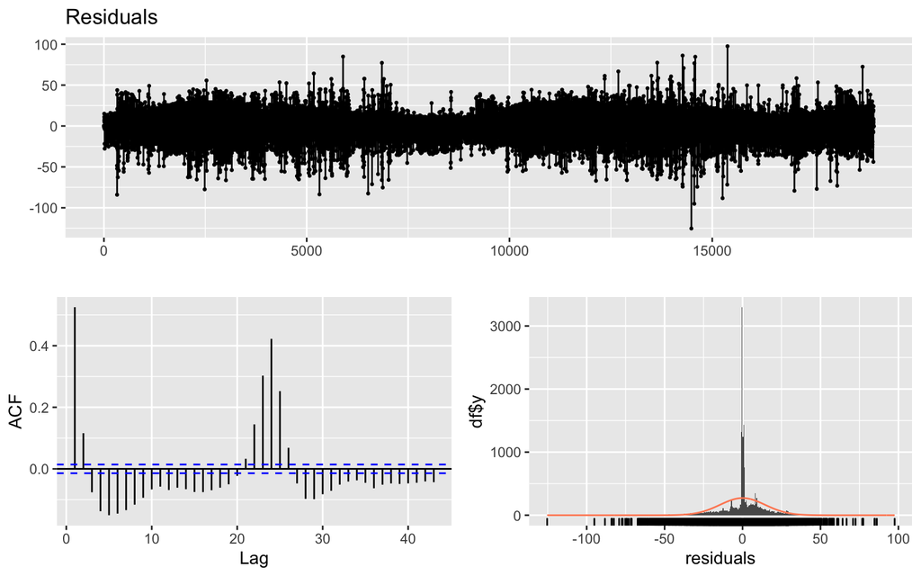

```
##
##  Breusch-Godfrey test for serial correlation of order up to 42
##
## data:  Residuals
## LM test = 8279.7, df = 42, p-value < 2.2e-16
```

Residuals seems to be in better situation compared to beginning. Even though it is necessary to do a residual analysis, I will use the model as this way for this task.

Now predictions will be made using this model. Since there are some empty cells in the data, some of the predictions cannot be made by using this regression model. To fill those empty prediction slots base model is used, which is basically taking the value of 48 hours before as the prediction. Below is the head of the vector of predictions.

```
##               datetime actual base_model tree_based_regression
## 1: 2021-11-01 00:00:00 0.0000          0             0.3438649
## 2: 2021-11-01 01:00:00 0.0000          0             0.3389802
## 3: 2021-11-01 02:00:00 0.0002          0             0.3400706
## 4: 2021-11-01 03:00:00 0.0001          0             0.3430784
## 5: 2021-11-01 04:00:00 0.0157          0             0.3572362
## 6: 2021-11-01 05:00:00 0.0000          0             0.9688790
```

## Discusssion and Conclusion

Now that the predictions are made, it’s time to compare the results of both models: tree-based regression model and the base model. To compare both methods, WMAPE, weighted mean absolute error rates are used as proposed in the task definition. Details of this metric can be found [here](https://en.wikipedia.org/wiki/WMAPE).

Statistics for Base Model

| N | Mean | Standard Deviation | Bias | MAD | WMAPE |
| --- | --- | --- | --- | --- | --- |
| 1296 | 45.36533 | 79.34344 | 0.0095345 | 22.57907 | 0.4977164 |

Statistics for Tree-Based Regression Model

| N | Mean | Standard Deviation | Bias | MAD | WMAPE |
| --- | --- | --- | --- | --- | --- |
| 1296 | 45.36533 | 79.34344 | -0.0638657 | 8.489223 | 0.1871302 |

As the statistics show, **Tree-Based Regression Model** is a lot better than the base model. Even though there could have been some better arrangements such as deeper residual analysis and adding some other related variables, or approaching to the data daily instead of hourly, this model proves that regression-tree approach made predictions su much better than the base model in terms of weighted mean absolute percentage error and mean absolute deviation metrics. Yet, 18% is still quite high, therefore it can be examined more deeply to improve it to a better model.

# References

Relevant data can be found [here](https://bu-ie-48b.github.io/fall21-ferhatturhan/files/production_with_weather_data.csv).

You can find the related R Markdown file and related R Codes [here](https://bu-ie-48b.github.io/fall21-ferhatturhan/files/homework4.Rmd).